# Introduction to treeclim

R Workshop, AmeriDendro 2016

Christian Zang

# Introduction

## Basic Usage

**treeclim** is an R package for the numerical calibration of proxy-climate relationships, developed with a focus on tree-ring data.

The workhorse function of **treeclim** is `dcc`, shorthand for “dendroclimatic calibration”. In its most simplest case, a growth-climate analysis can be performed like this:

```r
dc1 <- dcc(muc_spruce, muc_clim)
```

```
## Running for timespan 1950 - 2007...
```

For this first example, we use data that comes with **treeclim**: a chronology of *Picea abies* growing near Munich (Bavaria, Germany) together with corresponding monthly climate data (temperature and precipitation). The default configuration of `dcc`is to perform a bootstrapped response function analysis (Guiot 1991), using monthly climate variables from previous June to current September. The main difference here to other software (e.g., Dendroclim2002, Biondi and Waikul 2004) is that **treeclim** uses stationary bootstrapping (Politis and Romano 1994) by default, to account for potentially autocorrelated tree-ring data.

The resulting coefficients can be viewed by calling:

```r
dc1
```

```
## Coefficients (significance flags correspond to p < 0.05):
##               id varname month   coef significant ci_lower ci_upper
## prec.prev.jun  1    prec   jun  0.014       FALSE   -0.195    0.241
## prec.prev.jul  2    prec   jul -0.032       FALSE   -0.250    0.166
## prec.prev.aug  3    prec   aug -0.037       FALSE   -0.255    0.183
## prec.prev.sep  4    prec   sep  0.050       FALSE   -0.151    0.223
## prec.prev.oct  5    prec   oct  0.086       FALSE   -0.124    0.297
## prec.prev.nov  6    prec   nov -0.032       FALSE   -0.231    0.144
## prec.prev.dec  7    prec   dec  0.143       FALSE   -0.084    0.341
## prec.curr.jan  8    prec   JAN  0.090       FALSE   -0.138    0.345
## prec.curr.feb  9    prec   FEB  0.113       FALSE   -0.077    0.271
## prec.curr.mar 10    prec   MAR  0.036       FALSE   -0.226    0.325
## prec.curr.apr 11    prec   APR -0.130       FALSE   -0.347    0.067
## prec.curr.may 12    prec   MAY  0.070       FALSE   -0.145    0.257
## prec.curr.jun 13    prec   JUN  0.042       FALSE   -0.186    0.248
## prec.curr.jul 14    prec   JUL  0.122       FALSE   -0.088    0.379
## prec.curr.aug 15    prec   AUG -0.008       FALSE   -0.239    0.219
## prec.curr.sep 16    prec   SEP  0.076       FALSE   -0.177    0.291
## temp.prev.jun 17    temp   jun -0.081       FALSE   -0.272    0.125
## temp.prev.jul 18    temp   jul -0.022       FALSE   -0.217    0.165
## temp.prev.aug 19    temp   aug -0.112       FALSE   -0.323    0.098
## temp.prev.sep 20    temp   sep -0.028       FALSE   -0.245    0.191
## temp.prev.oct 21    temp   oct  0.212       FALSE   -0.070    0.423
## temp.prev.nov 22    temp   nov -0.109       FALSE   -0.306    0.140
## temp.prev.dec 23    temp   dec  0.163       FALSE   -0.062    0.419
## temp.curr.jan 24    temp   JAN -0.070       FALSE   -0.280    0.160
## temp.curr.feb 25    temp   FEB  0.134       FALSE   -0.125    0.363
## temp.curr.mar 26    temp   MAR  0.017       FALSE   -0.182    0.255
## temp.curr.apr 27    temp   APR -0.154       FALSE   -0.349    0.010
## temp.curr.may 28    temp   MAY  0.027       FALSE   -0.172    0.226
## temp.curr.jun 29    temp   JUN -0.028       FALSE   -0.343    0.297
## temp.curr.jul 30    temp   JUL  0.044       FALSE   -0.193    0.315
## temp.curr.aug 31    temp   AUG -0.086       FALSE   -0.320    0.236
## temp.curr.sep 32    temp   SEP  0.004       FALSE   -0.216    0.255
```

We see a table listing the monthly climatic predictors that have been generated by **treeclim** with the value of their corresponding coefficients, significance flags and confidence intervals. In this example, none of the climatic predictors turned out to be significant at a level of p < 0.05. (One important notice: the object returned by `dcc` is actually more complex than the table we get when print it. To access the coefficients, e.g. for writing your own plotting functions, you could use `coef(dc1)`.)

A basic plot is obtained by issueing:

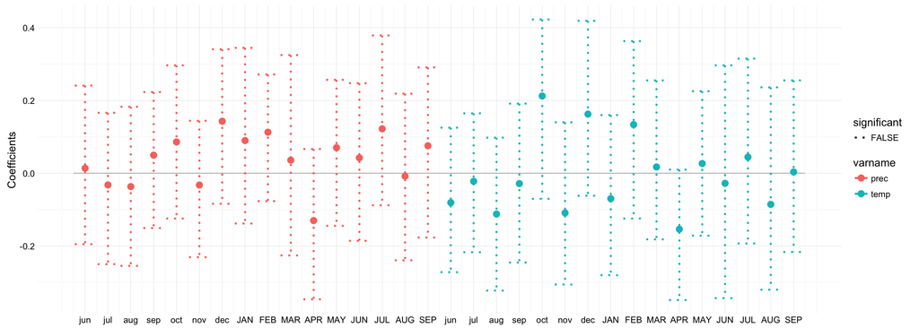

```r
plot(dc1)
```

We will see later how this plot can be styled to meet your personal preferences.

This was a very quick and basic introduction to the main functionality of **treeclim**. Everything else beyond that is refining the specification of your analysis. The next section details on the conceptual framework of **treeclim** and how it reflects in its design and usage.

Caution! Please make sure to have a recent version of treeclim (version >= 1.0.15) installed when you follow along the examples in this document.

## Citation

I enjoy writing **treeclim** and helping users, and Franco Biondi (of Dendroclim2002 fame) enjoys mentoring my work and collaborating closely to set the direction for this software package. Additional to improving citation metrics, getting proper credits for our work through correct citation also helps us to get an idea about who uses **treeclim** and for what. So, please make sure to cite **treeclim** correctly when you use it in your analyses:

```r
print(citation("treeclim"), style = "text")
```

```
## Zang C and Biondi F (2015). "treeclim: an R package for the
## numerical calibration of proxy-climate relationships."
## _Ecography_, *38*(4), pp. 431-436. ISSN 1600-0587, <URL:
## http://doi.org/10.1111/ecog.01335>.
```

The same applies to *R* in general and *dplR*, when you use it together with **treeclim** (which you definetively should, of course).

# The Five Elements of Growth-Climate-Relationships

Everyone looking at tree-growth as a function of climate will have to consider at least five elements of the analysis to be carried out:

- *Data*: which tree-ring and climate data shall be used
- *Design*: which climatic variables are considered interesting *a priori*, i.e. based on your assumptions about what is limiting tree growth for the site you are studying
- *Scope*: which subset of tree-ring and climate data shall be considered for the analysis
- *Method*: which method to use, i.e. response functions, correlation functions, or seasonal correlations
- *Dynamics*: shall the analysis be carried out in a static fashion, yielding one set of coefficients, or shall it be done in a dynamic fashion, allowing to look at time-varying response of tree-growth to climate.

The design of **treeclim** allows to build an analytic strategy considering these five elements. In the following, we will look at each element in some detail.

## Data

**treeclim** expects a tree-ring chronology as input, ideally as produced by the `chron` function in *dplR*. For climate data, two general formats are accepted:

1. *Year-Month* format: here, the climate data is formatted as a `data.frame` with columns `year`, `month`, and one column for each climatic variable like so:

```
##   year month temp  prec
## 1 1949     1 -0.4  44.9
## 2 1949     2 -0.7  19.2
## 3 1949     3  1.3  33.9
## 4 1949     4  9.8  58.9
## 5 1949     5 11.1 250.5
## 6 1949     6 13.1  70.7
```

It is important to note that **treeclim** can only work with data for which all years are complete, which means you might have to truncate your climate data if this is not the case.

2. *13-Column* format: here, for each climate variable a `data.frame` or numerical matrix is supplied with year as first column and monthly observations in columns 2 to 13 like so:

```
##   Year Jan Feb Mar Apr May Jun Jul Aug Sep Oct Nov Dec
## 1 1948 114  52  30  29  21  82 129  45   7  19  18  16
## 2 1949  40  22  44  46 101  24  12  35  35   6  21  54
## 3 1950  43  68  12  70  59  45  76 103  59  38 149  29
## 4 1951  54  45  28  14  44 137  55  34  25  33  60  44
## 5 1952  60  48 132  54  47  61   7  51 112  77 144  73
## 6 1953  20  22   3  38  45 124 116  29  29  26   8  26
```

To use more than one variable with this data format, you can supply them as a list to dcc like so: `dcc(chrono = rt_spruce, climate = list(rt_temp, rt_prec))`

For both climate data formats, there is no limit on the number of variables that can be used for the analyses. Please note that no missing values are allowed for both formats, so if your climate data contains missing values, consider interpolation or other imputation methods.

For the *13-Column* format, there are no obvious variable names for the climatic variables. If you want to have names, you can supply them using the `var_names` argument like so: `dcc(chrono = rt_spruce, climate = list(rt_temp, rt_prec), var_names = c("tmp", "pre"))`. This also works for renaming variables coming from the *Year-Month* format.

## Design

Being able to design a customized matrix of predictors is probably the most interesting part about `dcc`. The default design matrix will select all months from previous June to current September from all variables supplied to `dcc`. Since this is most of the times a good starting point, but not necessarily the ideal design matrix, you can easily specify a custom design matrix using a set of simple commands.

### Modifiers

In **treeclim**, there are three modifier functions for building the design matrix.

- `.range`: for selecting all months individually
- `.mean`: for building the mean over the specified months
- `.sum`: for summing up over the specified months

All modifiers have the same structure of `MODIFIER(.months, .variables)`, i.e. they take as arguments a number of months, and the variables for which the modifier shall be applied. Both arguments can be omitted; when `.months` is omitted, the default set of months (previous June to current September) is used, when `.variables` is omitted, the modifier will be applied to all available climate variables.

Here are two examples:

```r
dc2 <- dcc(muc_spruce, muc_clim, .range(-6:9, c("temp", "prec")))
```

```
## Running for timespan 1950 - 2007...
```

```r
rownames(dc2$coef)
```

```
##  [1] "prec.prev.jun" "prec.prev.jul" "prec.prev.aug" "prec.prev.sep"
##  [5] "prec.prev.oct" "prec.prev.nov" "prec.prev.dec" "prec.curr.jan"
##  [9] "prec.curr.feb" "prec.curr.mar" "prec.curr.apr" "prec.curr.may"
## [13] "prec.curr.jun" "prec.curr.jul" "prec.curr.aug" "prec.curr.sep"
## [17] "temp.prev.jun" "temp.prev.jul" "temp.prev.aug" "temp.prev.sep"
## [21] "temp.prev.oct" "temp.prev.nov" "temp.prev.dec" "temp.curr.jan"
## [25] "temp.curr.feb" "temp.curr.mar" "temp.curr.apr" "temp.curr.may"
## [29] "temp.curr.jun" "temp.curr.jul" "temp.curr.aug" "temp.curr.sep"
```

This is identical with the default configuration and can be written more concise as `dcc(muc_spruce, muc_clim, -6:9)`. Another example:

```r
dc3 <- dcc(muc_spruce, muc_clim, .sum(5:9, c("temp", "prec")))
```

```
## Running for timespan 1949 - 2007...
```

```r
dc3
```

```
## Coefficients (significance flags correspond to p < 0.05):
##                                             id  varname     month   coef
## prec.sum.curr.may.cu...ul.curr.aug.curr.sep  1 prec.sum MAY...SEP  0.129
## temp.sum.curr.may.cu...ul.curr.aug.curr.sep  2 temp.sum MAY...SEP -0.129
##                                             significant ci_lower ci_upper
## prec.sum.curr.may.cu...ul.curr.aug.curr.sep       FALSE   -0.098    0.308
## temp.sum.curr.may.cu...ul.curr.aug.curr.sep       FALSE   -0.310    0.098
```

### Exclusion

It can be desireable to exclude some time spans from analysis, for example dormant seaons. For this task, **treeclim** has the function `exclude_from` (or `exfr` for short) to exclude specific months from being integrated into the predictors build using the modifier functions.

```r
dc4 <- dcc(muc_spruce, muc_clim, .range(exfr(-6:9, -10:2)))
```

```
## Running for timespan 1950 - 2007...
```

```r
rownames(dc4$coef)
```

```
##  [1] "prec.prev.jun" "prec.prev.jul" "prec.prev.aug" "prec.prev.sep"
##  [5] "prec.curr.mar" "prec.curr.apr" "prec.curr.may" "prec.curr.jun"
##  [9] "prec.curr.jul" "prec.curr.aug" "prec.curr.sep" "temp.prev.jun"
## [13] "temp.prev.jul" "temp.prev.aug" "temp.prev.sep" "temp.curr.mar"
## [17] "temp.curr.apr" "temp.curr.may" "temp.curr.jun" "temp.curr.jul"
## [21] "temp.curr.aug" "temp.curr.sep"
```

In this example, we excluded autumn and winter months October (previous year) to February (current year) from the analysis. The remaining months from `.range(-6:9)` were selected as individual months for building the design matrix, because we used the `.range` modifier. Often, as here, it is not necessary to explicitly use `.range`, and `dcc(..., exfr(-6:9, -10:2))` would have done the same thing.

### Modifier Chaining

The last component for building design matrix is introduced by the ability to chain modifiers. This is done using the `+` operator:

```r
dc5 <- dcc(muc_spruce, muc_clim, .sum(-4:-9, "prec") +
             .sum(4:9, "prec") + .range(exfr(-6:9, -10:3), "temp"))
```

```
## Running for timespan 1950 - 2007...
```

```r
dc5
```

```
## Coefficients (significance flags correspond to p < 0.05):
##                                             id  varname     month   coef
## prec.sum.prev.apr.pr...ul.prev.aug.prev.sep  1 prec.sum apr...sep  0.037
## prec.sum.curr.apr.cu...ul.curr.aug.curr.sep  2 prec.sum APR...SEP  0.179
## temp.prev.jun                                3     temp       jun -0.121
## temp.prev.jul                                4     temp       jul -0.062
## temp.prev.aug                                5     temp       aug -0.072
## temp.prev.sep                                6     temp       sep -0.017
## temp.curr.apr                                7     temp       APR -0.135
## temp.curr.may                                8     temp       MAY  0.099
## temp.curr.jun                                9     temp       JUN -0.005
## temp.curr.jul                               10     temp       JUL  0.004
## temp.curr.aug                               11     temp       AUG -0.047
## temp.curr.sep                               12     temp       SEP  0.033
##                                             significant ci_lower ci_upper
## prec.sum.prev.apr.pr...ul.prev.aug.prev.sep       FALSE   -0.138    0.208
## prec.sum.curr.apr.cu...ul.curr.aug.curr.sep       FALSE   -0.028    0.400
## temp.prev.jun                                     FALSE   -0.291    0.087
## temp.prev.jul                                     FALSE   -0.239    0.111
## temp.prev.aug                                     FALSE   -0.281    0.127
## temp.prev.sep                                     FALSE   -0.243    0.223
## temp.curr.apr                                     FALSE   -0.315    0.037
## temp.curr.may                                     FALSE   -0.174    0.343
## temp.curr.jun                                     FALSE   -0.288    0.297
## temp.curr.jul                                     FALSE   -0.275    0.256
## temp.curr.aug                                     FALSE   -0.264    0.294
## temp.curr.sep                                     FALSE   -0.186    0.250
```

Here, we are using two precipitation sums (corresponding to the previous and current growing seasons), and a range of month-wise temperatures excluding a dormant season. We can chain as many modifiers as we want. Using modifiers, exclusion and modifier chaining, we can create as complex (or simple) design matrices as needed.

### Redundancy Check

While **treeclim** will check carefully that no two predictors are exactly the same, it can by no means check if the specification of the design matrix makes any sense at all.

## Scope

By default, **treeclim** will use the maximum timespan available for both tree-ring and climate data. This can be changed using the `timespan` argument: `dcc(..., timespan = c(1965, 2000))` will run the analysis using the timespan from 1965 to 2000. When the number of years for the analysis becomes smaller than the number of predictors in the design matrix, **treeclim** will raise an error.

## Method

With `dcc`, one may choose between response function analysis (the default) and correlation function analysis using the `method` argument: `dcc(..., method = "correlation")` will switch to the correlation method. A third method is available: seasonal correlations. The rationale behind this approach developed by Dave Meko (Meko et al. 2011) is somewhat different, which is why it deserves its own function `seascorr`.

## Dynamics

The temporal stability of climate-growth-relations can be analysed using moving response and correlation functions. By default, `dcc` computes static analyses, but by setting the `moving`argument to `TRUE`, the analyses will be repeated in shifting time windows.

```r
dc6 <- dcc(chrono = muc_spruce, climate = muc_clim,
           selection = 4:10, moving = TRUE, sb = FALSE)
dc6
```

```
## Coefficients (significance flags correspond to p < 0.05):
##               1949-1973 1950-1974 1951-1975 1952-1976 1953-1977 1954-1978
## prec.curr.apr "-0.2"    "-0.145"  "-0.259"  "-0.091"  "-0.14"   "-0.236"
## prec.curr.may "-0.046"  "-0.18"   "-0.04"   "-0.052"  "0.043"   "0.062"
## prec.curr.jun "0.062"   "0.113"   "0.129"   "0.304"   "0.368"   "0.31"
## prec.curr.jul "0.143"   "0.159"   "0.164"   "0.03"    "0.083"   "0.204"
## prec.curr.aug "0.147"   "0.115"   "-0.042"  "-0.072"  "-0.09"   "-0.146"
## prec.curr.sep "0.11"    "0.025"   "-0.102"  "-0.12"   "-0.154"  "-0.258"
## prec.curr.oct "-0.076"  "-0.056"  "0.014"   "0.149"   "0.154"   "0.098"
## temp.curr.apr "-0.183"  "-0.194"  "-0.213"  "-0.182"  "-0.192"  "-0.185"
## temp.curr.may "0.126"   "0.146"   "0.093"   "-0.005"  "0.011"   "0.004"
## temp.curr.jun "0.139"   "0.171"   "0.215"   "0.041"   "0.036"   "0.021"
## temp.curr.jul "0.159"   "0.154"   "0.041"   "0.01"    "-0.041"  "-0.034"
## temp.curr.aug "-0.121"  "-0.119"  "-0.113"  "-0.032"  "-0.047"  "-0.121"
## temp.curr.sep "0.161"   "0.114"   "-0.018"  "0.03"    "0.097"   "0.105"
## temp.curr.oct "-0.002"  "0.065"   "0.218"   "0.16"    "0.158"   "0.153"
##               1955-1979 1956-1980 1957-1981 1958-1982 1959-1983 1960-1984
## prec.curr.apr "-0.155"  "-0.075"  "-0.127"  "-0.146"  "-0.093"  "-0.132"
## prec.curr.may "-0.004"  "-0.018"  "-0.033"  "-0.065"  "-0.088"  "-0.089"
## prec.curr.jun "0.213"   "0.202"   "0.148"   "0.063"   "0.045"   "0.036"
## prec.curr.jul "0.28"    "0.24"    "0.365"   "0.251"   "0.163"   "0.148"
## prec.curr.aug "-0.195"  "-0.167"  "-0.256"  "-0.205"  "-0.159"  "-0.074"
## prec.curr.sep "-0.224"  "-0.231"  "-0.107"  "-0.113"  "-0.034"  "0.125"
## prec.curr.oct "0.07"    "0.106"   "0.232"   "0.216"   "0.184"   "0.179"
## temp.curr.apr "-0.105"  "-0.088"  "-0.056"  "-0.083"  "-0.017"  "-0.121"
## temp.curr.may "0.064"   "0.05"    "0.048"   "0.139"   "0.06"    "-0.026"
## temp.curr.jun "-0.142"  "-0.144"  "-0.082"  "-0.043"  "-0.007"  "-0.023"
## temp.curr.jul "-0.235"  "-0.248"  "-0.22"   "-0.157"  "-0.018"  "-0.026"
## temp.curr.aug "-0.118"  "-0.039"  "-0.043"  "0.007"   "0.096"   "0.119"
## temp.curr.sep "0.142"   "0.131"   "0.203"   "0.298"   "0.289"   "0.283"
## temp.curr.oct "0.227"   "0.232"   "0.258"   "0.277"   "0.31"    "0.399*"
##               1961-1985 1962-1986 1963-1987 1964-1988 1965-1989 1966-1990
## prec.curr.apr "-0.113"  "-0.104"  "-0.132"  "-0.188"  "-0.107"  "-0.086"
## prec.curr.may "-0.038"  "-0.025"  "-0.003"  "-0.038"  "-0.058"  "-0.023"
## prec.curr.jun "0.002"   "0.015"   "-0.029"  "-0.022"  "-0.051"  "-0.004"
## prec.curr.jul "0.111"   "0.085"   "0.1"     "0.161"   "0.166"   "0.175"
## prec.curr.aug "-0.005"  "0.002"   "-0.064"  "-0.069"  "-0.124"  "-0.116"
## prec.curr.sep "0.08"    "0.109"   "0.078"   "0.018"   "0.041"   "0.091"
## prec.curr.oct "0.163"   "0.153"   "0.099"   "0.037"   "0.09"    "0.102"
## temp.curr.apr "-0.151"  "-0.123"  "-0.081"  "-0.001"  "0.016"   "-0.026"
```

[output cut: 36 more lines]

```
##               1979-2003 1980-2004 1981-2005 1982-2006 1983-2007
## prec.curr.apr "0.09"    "0.093"   "0.064"   "0.061"   "0.148"
## prec.curr.may "0.078"   "0.125"   "0.104"   "0.114"   "0.18"
## prec.curr.jun "-0.212"  "-0.116"  "-0.096"  "0.006"   "-0.007"
## prec.curr.jul "0.083"   "0.083"   "0.066"   "0.138"   "0.111"
## prec.curr.aug "0.083"   "0.135"   "0.131"   "0.133"   "0.094"
## prec.curr.sep "0.199"   "0.244"   "0.28"    "0.232"   "0.304"
## prec.curr.oct "-0.001"  "0.015"   "0.029"   "-0.12"   "-0.088"
## temp.curr.apr "-0.181"  "-0.277"  "-0.316"  "-0.298"  "-0.254"
## temp.curr.may "-0.074"  "0.014"   "-0.006"  "0.033"   "0.045"
## temp.curr.jun "-0.139"  "-0.103"  "-0.11"   "-0.126"  "-0.185"
## temp.curr.jul "-0.08"   "-0.065"  "-0.071"  "-0.158"  "-0.197"
## temp.curr.aug "-0.271"  "-0.352"  "-0.312"  "-0.149"  "-0.12"
## temp.curr.sep "0.102"   "0.082"   "0.086"   "-0.044"  "-0.084"
## temp.curr.oct "0.118"   "0.011"   "0.015"   "-0.088"  "-0.106"
```

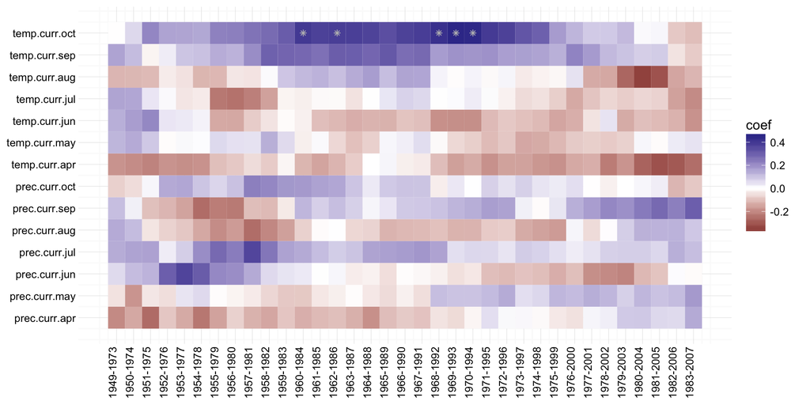

```r
plot(dc6)
```

The stars in the plot indicate windows with significant correlations for the given variable. Like in the non-dynamic case, you are free to create a customized design matrix using the **treeclim** modifiers. Further options comprise the window size, the window offset (the gap between consecutive window starts), and whether to start with windowing from the most recent end (default), or from the least recent end.

If `method` is set to `correlation` for computing a moving correlation function, we can use `g_test` to test the temporal fluctuations of the correlation coefficients for significance by comparing them to the magnitude of fluctuations that would occur by chance alone (using a multivariate extension of the approach by Gershunov et al. 2001):

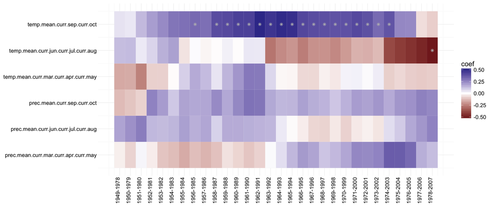

```r
dc7 <- dcc(chrono = muc_spruce, climate = muc_clim,
           selection = .mean(3:5) + .mean(6:8) + .mean(9:10), method = "cor",
           moving = TRUE, win_size = 30, sb = FALSE)
plot(dc7)
```

```r
g_test(dc7, sb = FALSE)
```

```
## Performing test without bootstrapping individual correlations.
```

```
##     varname     month     p
## 1 temp.mean SEP...OCT 0.088
## 2 temp.mean JUN...AUG 0.034
## 3 temp.mean MAR...MAY 0.260
## 4 prec.mean SEP...OCT 0.388
## 5 prec.mean JUN...AUG 0.350
## 6 prec.mean MAR...MAY 0.104
```

In this example, only the fluctuations in the correlation coefficient for mean temperature from current June to current August are significant at a level of p < 0.05. This means, that the probability of an even larger fluctuation by chance is less than 0.05. For more details, look into `?g_test`.

# Seasonal Correlations

**treeclim** provides similar functionality to Dave Meko’s *seascorr* MATLAB program: partial correlations for a primary and a secondary climatic variable for seasons of different lengths. The tree-ring and climate input data is required in the same format as for `dcc`.

```r
sc1 <- seascorr(muc_spruce, muc_clim)
```

```
## Running for timespan 1949 - 2007...
```

```r
sc1
```

```
## Results for a season length of 1 month:
##    month      type         coef significant
## 1    aug   primary -0.201352878       FALSE
## 2    sep   primary -0.046407397       FALSE
## 3    oct   primary  0.289828779       FALSE
## 4    nov   primary -0.229822307       FALSE
## 5    dec   primary  0.213082268       FALSE
## 6    JAN   primary -0.058629796       FALSE
## 7    FEB   primary  0.194546770       FALSE
## 8    MAR   primary  0.096562239       FALSE
## 9    APR   primary -0.216711508       FALSE
## 10   MAY   primary -0.002871121       FALSE
## 11   JUN   primary -0.081162622       FALSE
## 12   JUL   primary -0.040510905       FALSE
## 13   AUG   primary -0.122882799       FALSE
```

[output cut: 77 more lines]

This is the default configuration for `seascorr`: considering three different season lengths (1, 3, and 6 months), and current September as month where tree-ring growth is assumed to have finished. There is a plot method available as well:

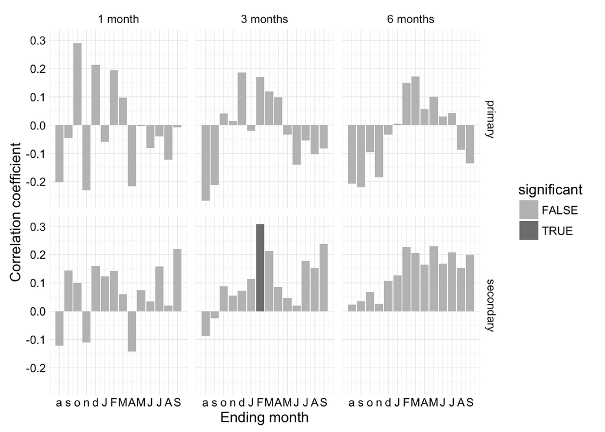

```r
plot(sc1)
```

```r
sc2 <- seascorr(muc_spruce, muc_clim, primary = "prec", secondary = "temp")
```

```
## Running for timespan 1949 - 2007...
```

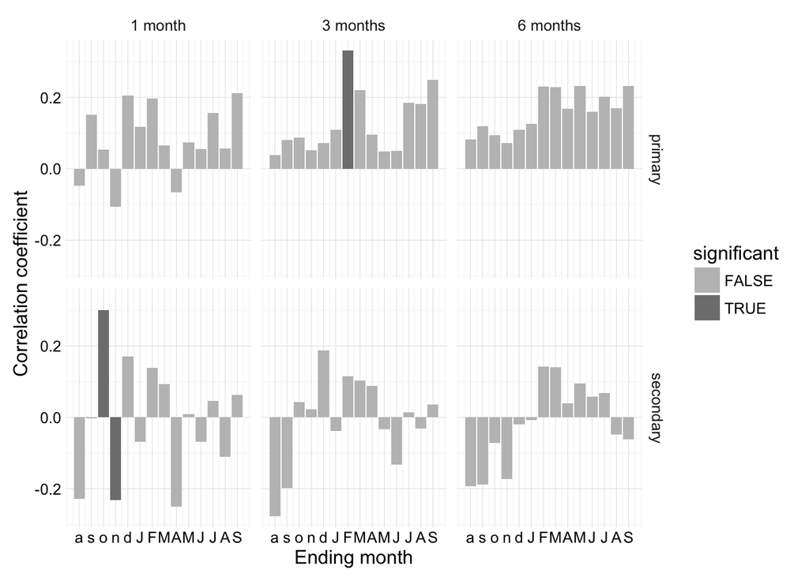

```r
plot(sc2)
```

# Reconstruction Skills

**treeclim** offers some basic functionality for evaluating the reconstruction skills of tree-ring chronologies via the `skills` function. `skills` works on existing output from either `dcc` or `seascorr` and tests the prediction skills of the tree-ring data for a given climate target. For this example, we use a different built-in data set, a chronology of pines from Visdalen in Norway (consult `?norw015` for details) and associated climate data:

```r
dc8 <- dcc(norw015, list(norway_prec, norway_temp), 3:9, var_names = c("prec", "temp"))
```

```
## Running for timespan 1901 - 1983...
```

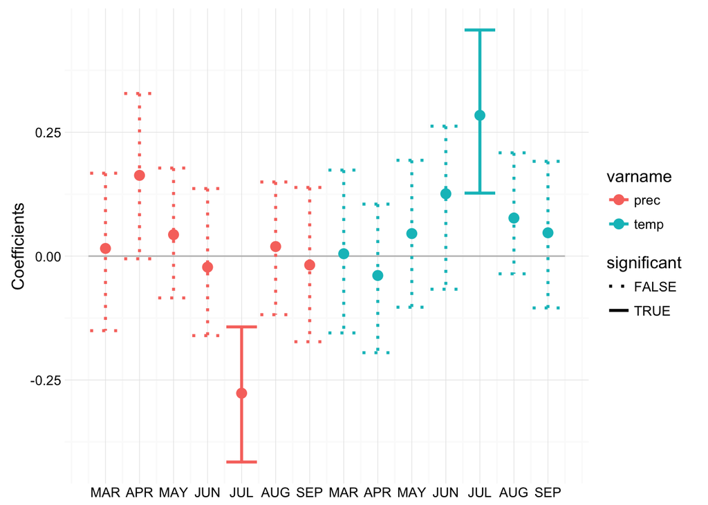

```r
plot(dc8)
```

Let us assume we are interested in reconstructing summer temperatures, and want to make use of the significant correlation with July temperature. We call `skills` on the `dc8` object, and specify `.range(7, "temp")` as target to get July temperature as response variable (note that for `skills`, like in many dendroclimatic applications, climate is modelled subject to tree-ring data):

```r
sk8 <- skills(dc8, .range(7, "temp"))
sk8
```

```
## Call:
## skills(object = dc8, target = .range(7, "temp"))
##
## Using climate target temp.curr.jul and calibration model with 50 percent (= 42 years) of data starting at recent end as calibration period:
##
##          r     p-value
## 0.54389486  0.00990099
##
## Coefficients:
## intercept      slope
##  8.571702   3.237617
##
## Verification statistics:
##        Red. of Error (RE)  Coeff. of Efficiency (CE)
##                     0.032                      0.004
##
## Durbin-Watson Test (DW): 1.628 (p = 0.09401695)
##
## Model for whole period:
##
##          r     p-value
## 0.44574375  0.00990099
##
## Coefficients:
## intercept      slope
##  9.156851   2.967707
```

By default, `skills` will take the maximum available timespan and divide it into equally sized calibration and verification periods. Reported are the parameter estimates and goodness of fit for the calibration and full models, plus some established verification statistics. Here, both RE and CE are positive, so the reconstruction has some skills at least. We can also look at the reconstruction:

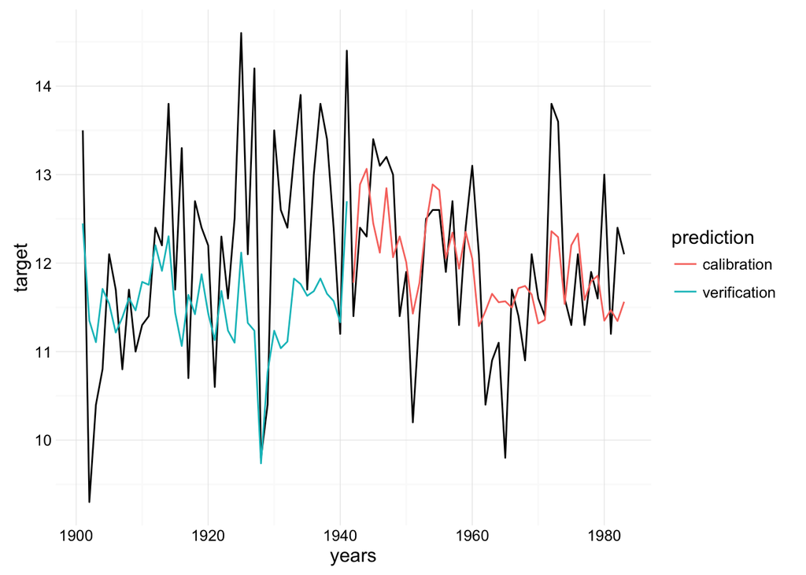

```r
plot(sk8)
```

The specification of the calibration period in `skills` is quite flexible, you might want to look in to `?skills` for more details. Furthermore, you can chose between an OLS regression model (default) or an RMA regression.

# Plotting

**treeclim** uses **ggplot2** (Wickham 2009) to build its plots. **ggplot2**-plots are themeable and easily be customized. This means, it only takes a few lines of code to adapt your **treeclim** output to your aesthetical preferences.

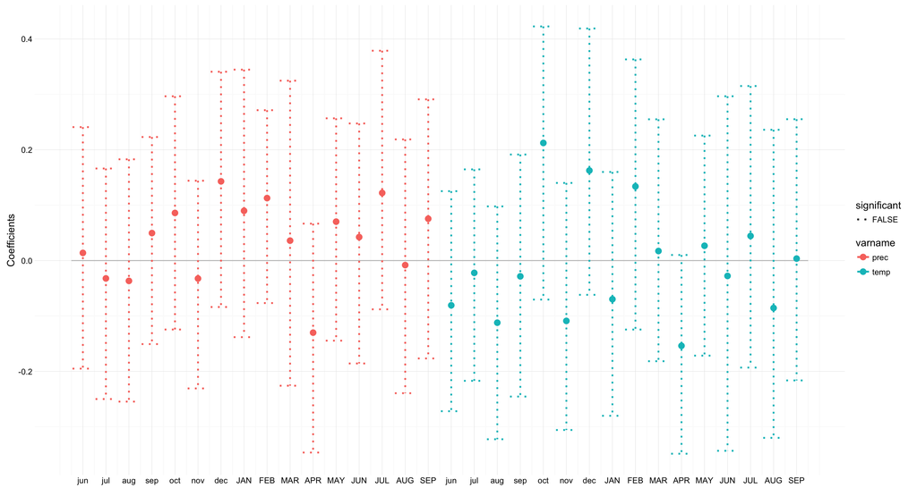

```r
plot(dc1)
```

This is the default. If we feel the default style does not blend in nicely with our gothic inspired interior design, we can always change some things (we need to include **ggplot2** for this):

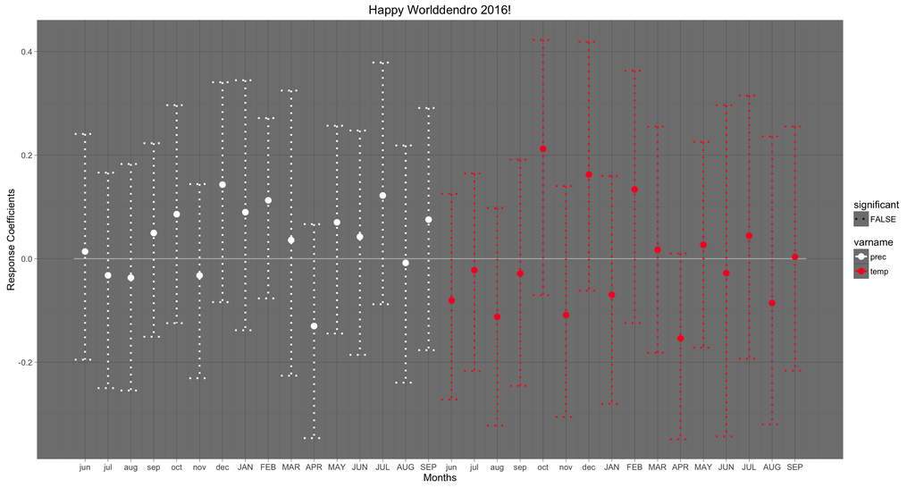

```r
library(ggplot2)
plot(dc1) + theme_dark() + scale_color_manual(values = c("#FFFFFF", "#F62525")) +
  ylab("Response Coefficients") + ggtitle("Happy Worlddendro 2016!")
```

You may want to consult the **ggplot2** documentation for further options (there are many).

# Conclusion & Acknowledgements

**treeclim** tries to provide a flexible framework for the exploration of tree-climate-relationships. **treeclim** does not impose complexity on the user, and keeps simple things simple. When needed, however, functionality is available to adapt to various research questions. Most aspects of what **treeclim** can do has been touched in this vignette. There are few more options that are potentially interesting, such as the ability to use different bootstrapping schemes with `dcc`.

Areas where **treeclim** is currently lacking include better support of southern hemisphere data by providing access to climate data from the year before the previous one. Also, testing reconstructing skills is only basic.

Some of the features currently implemented derive from requests by the user community (`seascorr` being the most prominent example), and I am grateful for these and further suggestions.

# Citations

Biondi, F., and K. Waikul. 2004. DENDROCLIM2002: A C++ program for statistical calibration of climate signals in tree-ring chronologies. Computers in Geosciences 30:303–311.

Gershunov, A., N. Schneider, and T. Barnett. 2001. Low-frequency modulation of the ENSO-Indian Monsoon rainfall relationship: Signal or noise? Journal of Climate 14:2486–2492.

Guiot, J. 1991. The bootstrapped response function. Tree Ring Bulletin 51:39–41.

Meko, D. M., R. Touchan, and K. J. Anchukaitis. 2011. Seascorr: A MATLAB program for identifying the seasonal climate signal in an annual tree-ring time series. Computers & Geosciences 37:1234–1241.

Politis, D. N., and J. P. Romano. 1994. The stationary bootstrap. Journal of the American Statistical Association 89:1303–1313.

H. Wickham. ggplot2: Elegant Graphics for Data Analysis. Springer-Verlag New York, 2009.